# 2. Dose-Response Data Processing

#### 5.2.1.9 SK-MEL-28

🔍 Zoom In for Details

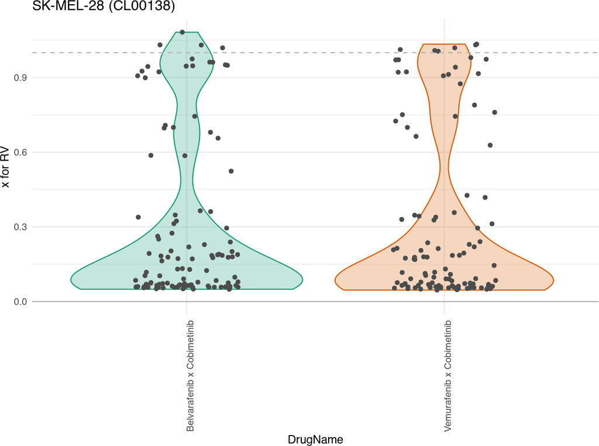

#### 5.2.1.10 WM-266-4

🔍 Zoom In for Details

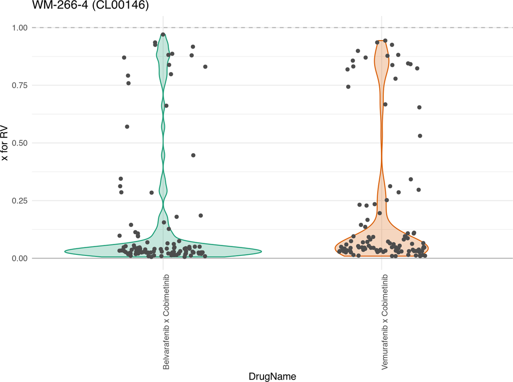

### 5.2.2 GR Value

#### 5.2.2.1 A-375

🔍 Zoom In for Details

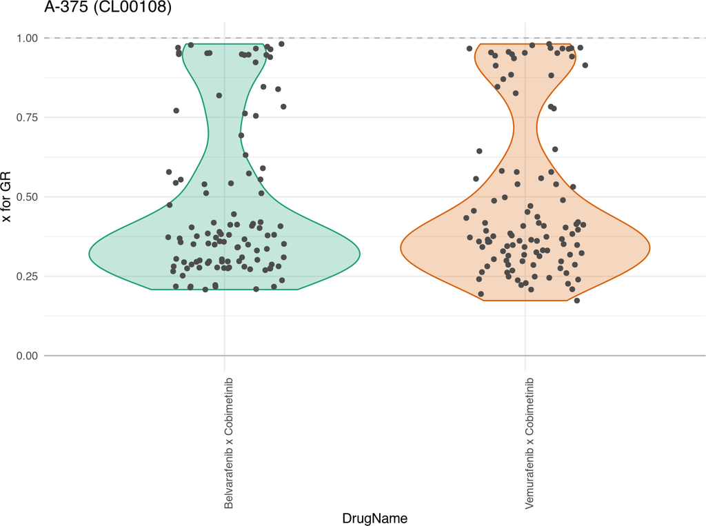

#### 5.2.2.2 A-431

🔍 Zoom In for Details

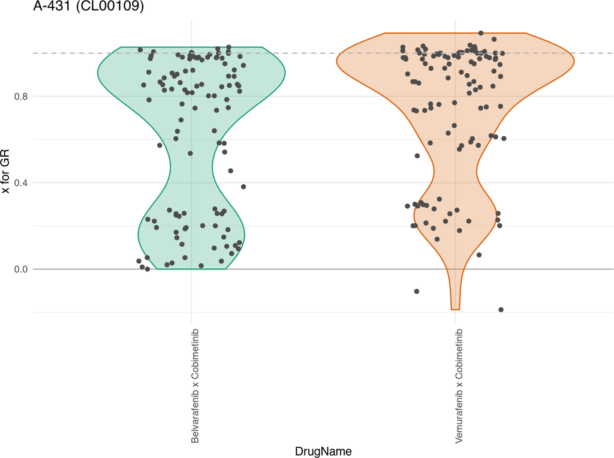

#### 5.2.2.3 A2058

🔍 Zoom In for Details

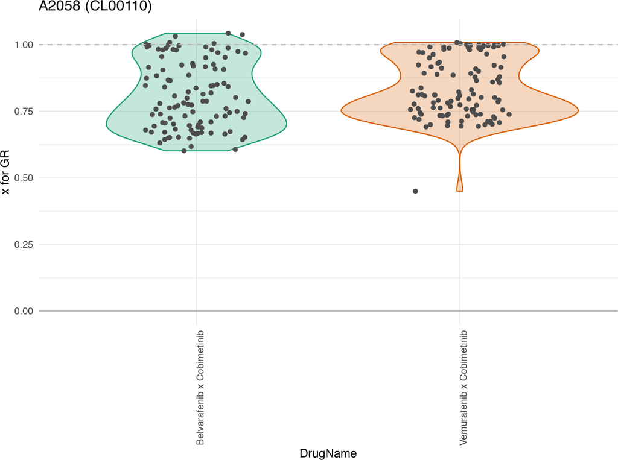

#### 5.2.2.4 COLO 800

🔍 Zoom In for Details

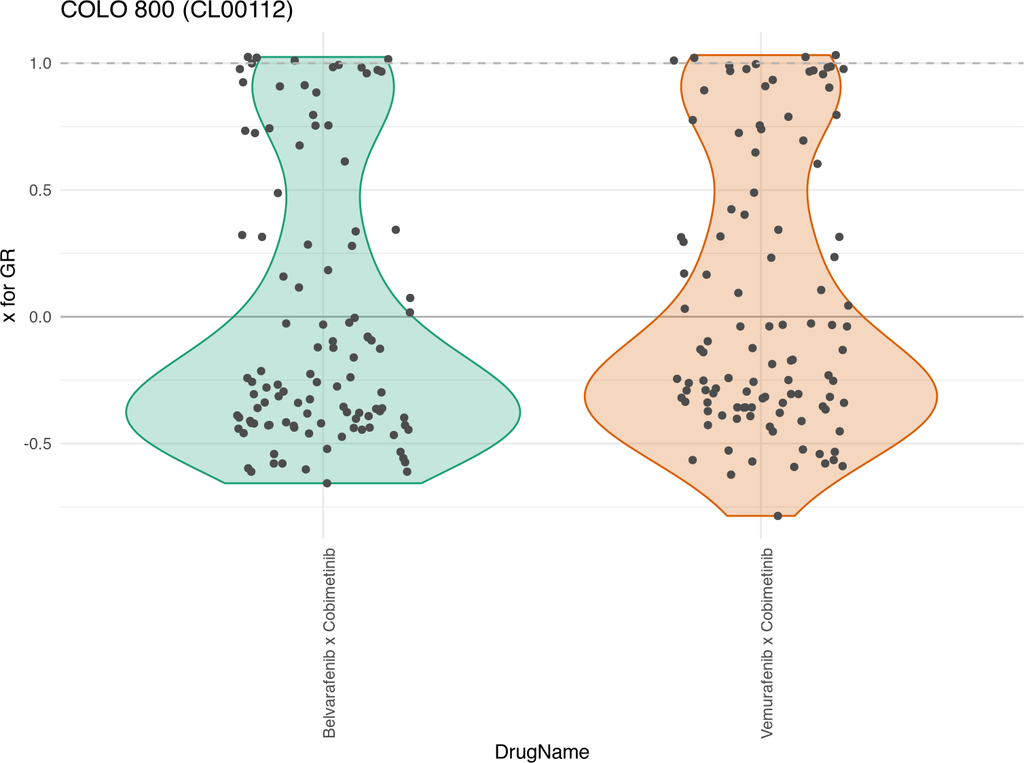

#### 5.2.2.5 COLO 829

🔍 Zoom In for Details

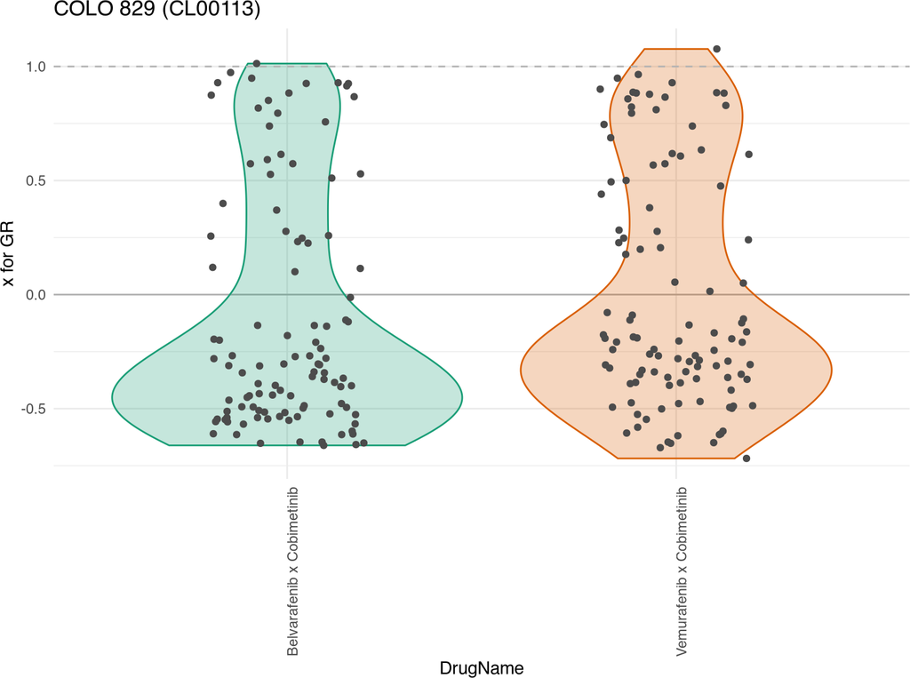

#### 5.2.2.6 HSC-1

🔍 Zoom In for Details

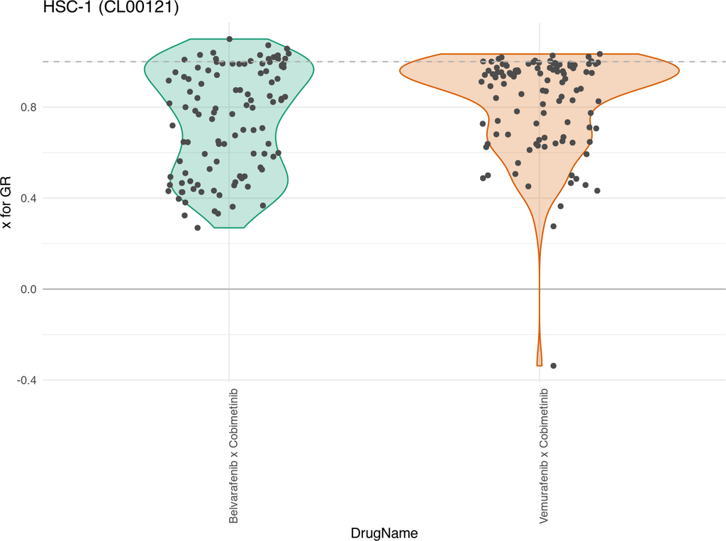

#### 5.2.2.7 HT-144

🔍 Zoom In for Details

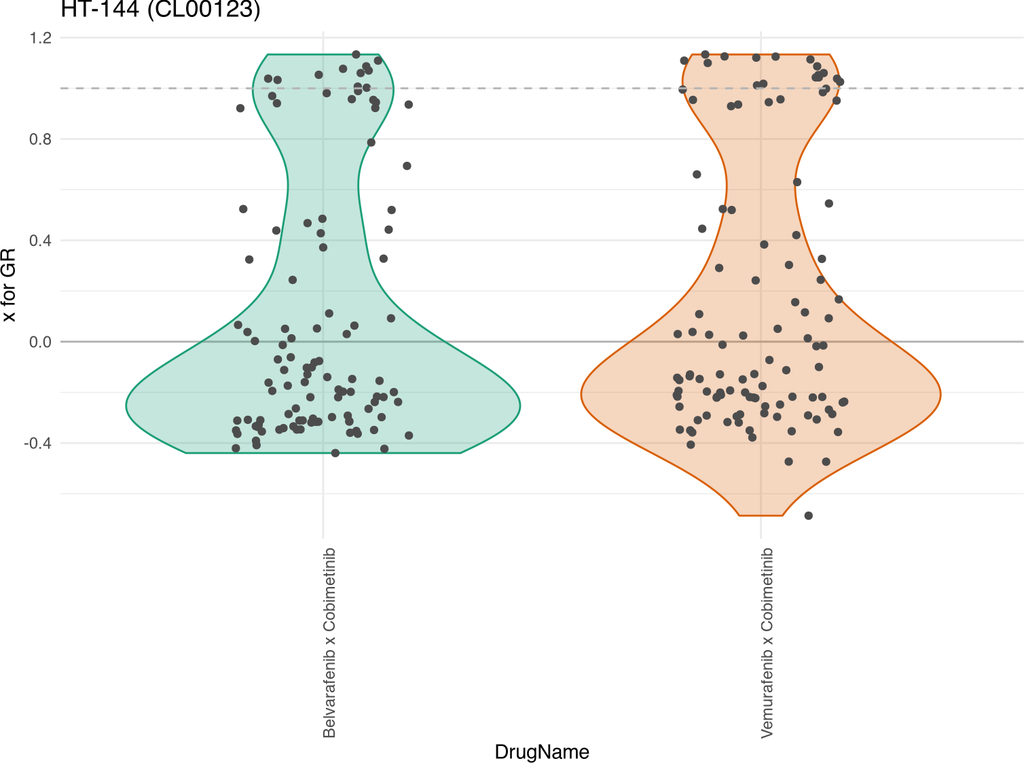

#### 5.2.2.8 MEL-JUSO

🔍 Zoom In for Details

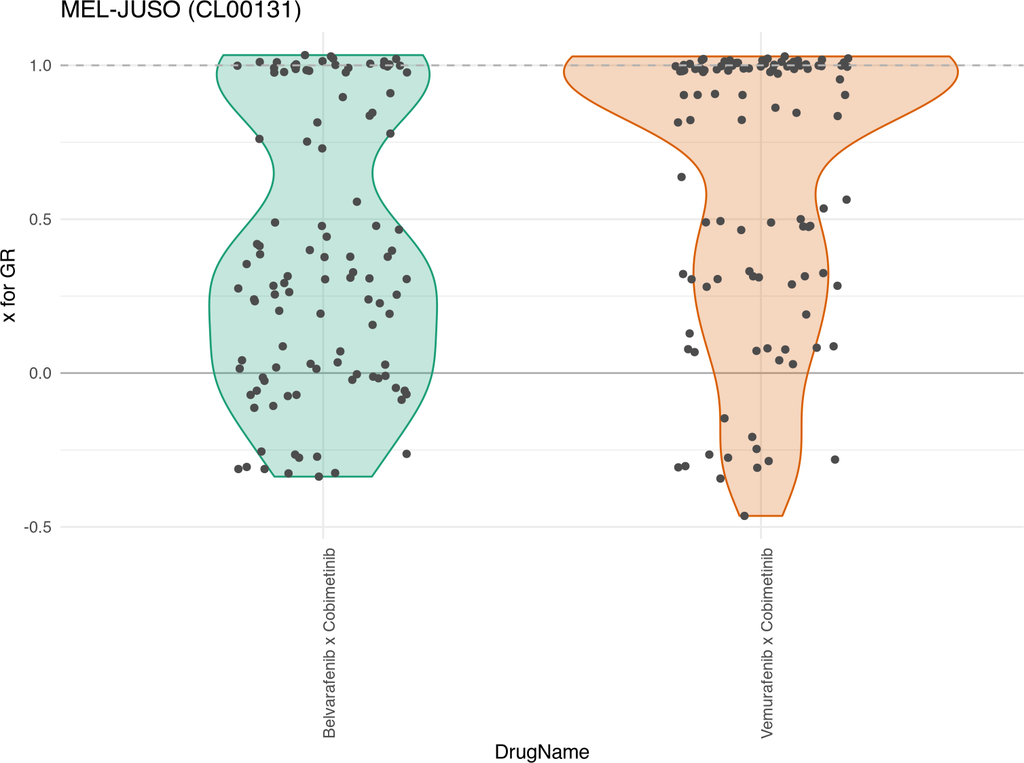

#### 5.2.2.9 SK-MEL-28

🔍 Zoom In for Details

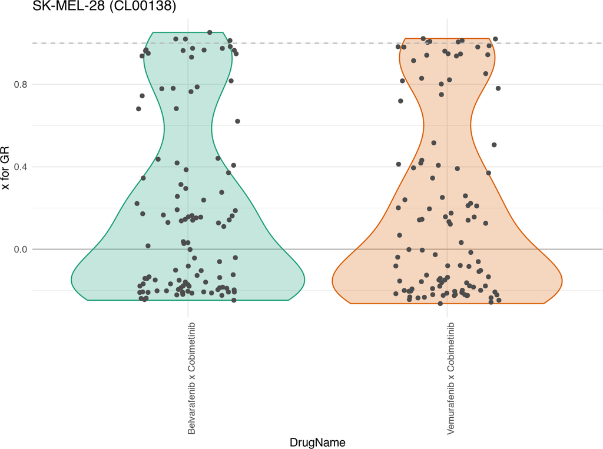

#### 5.2.2.10 WM-266-4

🔍 Zoom In for Details

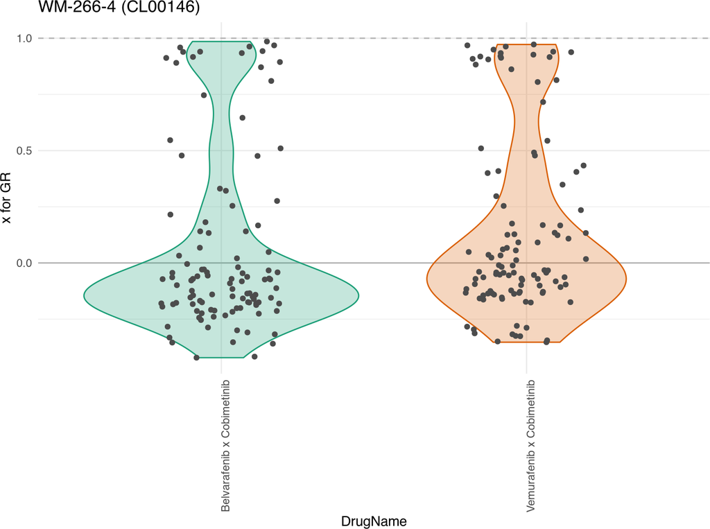

# 6 Average Replicate Data

Technical replicates are averaged to produce a single dose-response data point for each unique treatment condition. This step also calculates the standard deviation for the replicates and creates the `Averaged` assay.

```r
se_sa <- average_SE(se_sa, data_type = sa_name)
```

```r
se_combo <- average_SE(se_combo, data_type = combo_name)
```

## 6.1 Quality Control: Averaged Data - Single-Agent Data

These heatmaps provide an overview of the averaged response data across all drugs and cell lines. One heatmap shows the mean response, and the other shows the variance (standard deviation).

```r
response_data_sa <- convert_se_assay_to_dt(se = se_sa,
                                           assay_name = "Averaged",
                                           unify_metadata = TRUE,
                                           merge_additional_variables = TRUE)
# metrics
metrics <- data.table(metric = c("x", "x_std"))

metrics$hm_title <- paste("RV", c("value", "variance"))
ls_plt_RV <- pmap(metrics,
                  pheatmap_qc,
                  dt_average = response_data_sa,
                  normalization_type = "RV",
                  lbl_by_CellLineName = TRUE,
                  lbl_by_DrugName = TRUE)
names(ls_plt_RV) <- metrics$hm_title
```

```r
metrics$hm_title <- paste("GR", c("value", "variance"))
ls_plt_GR <- pmap(metrics,
                  pheatmap_qc,
                  dt_average = response_data_sa,
                  normalization_type = "GR",
                  lbl_by_CellLineName = TRUE,
                  lbl_by_DrugName = TRUE)
names(ls_plt_GR) <- metrics$hm_title
```

### 6.1.1 Relative Viability

#### 6.1.1.1 RV value

🔍 Zoom In for Details

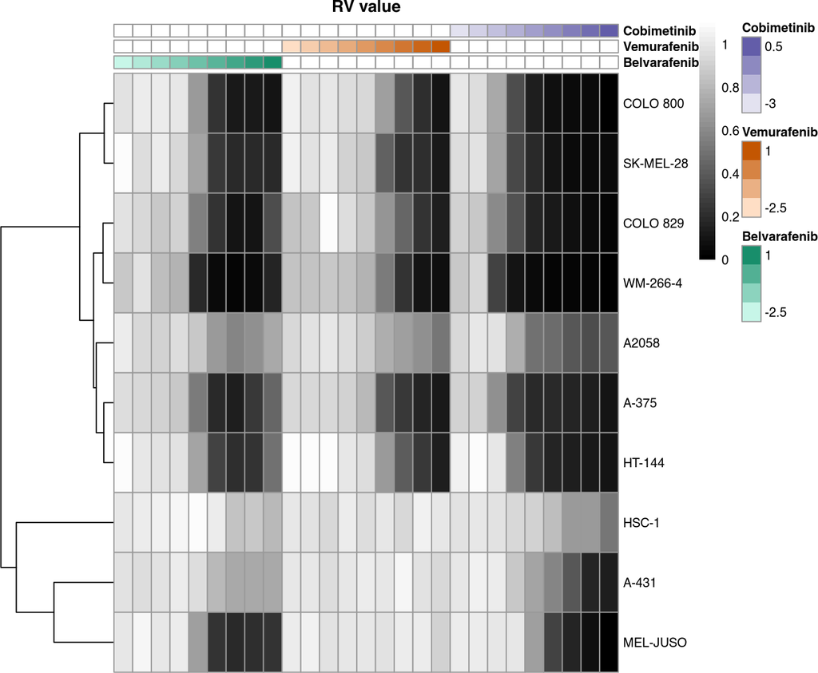

#### 6.1.1.2 RV variance

🔍 Zoom In for Details

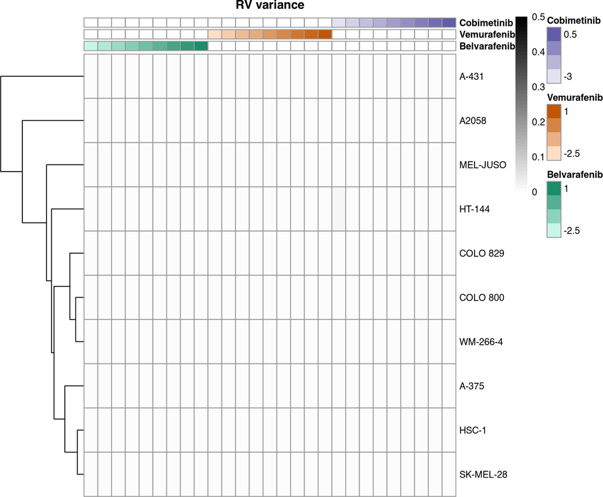

### 6.1.2 GR Value

#### 6.1.2.1 GR value

🔍 Zoom In for Details

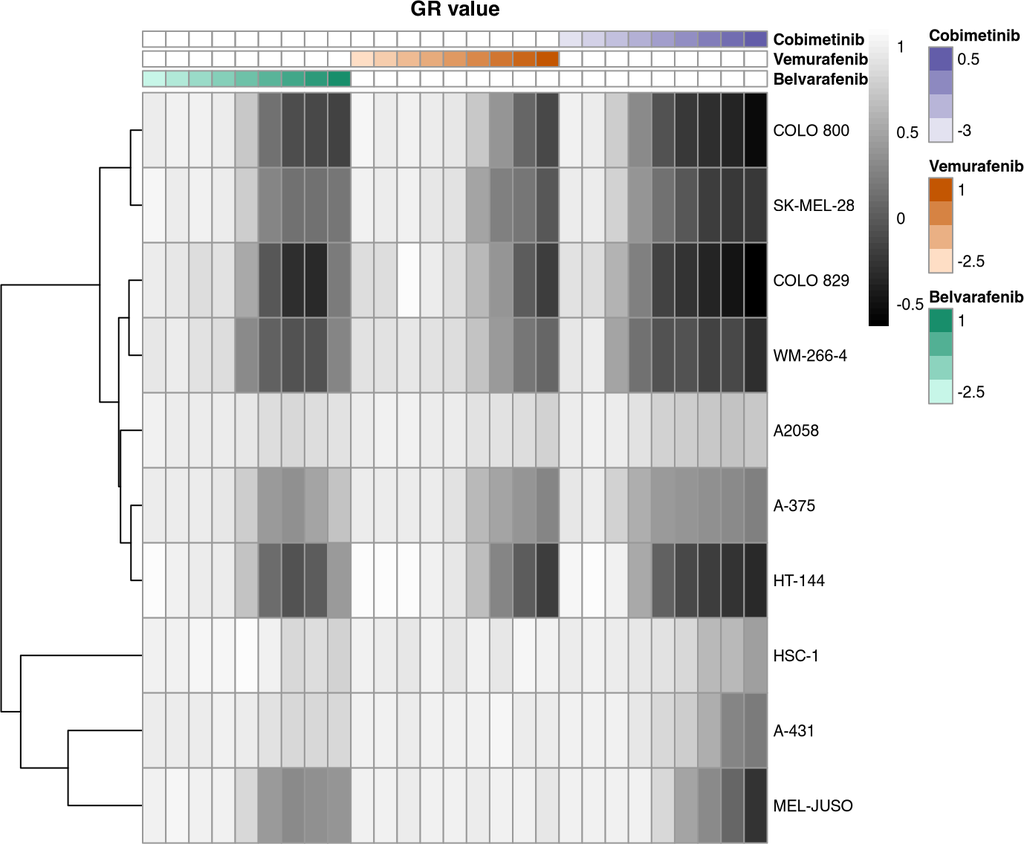

#### 6.1.2.2 GR variance

🔍 Zoom In for Details

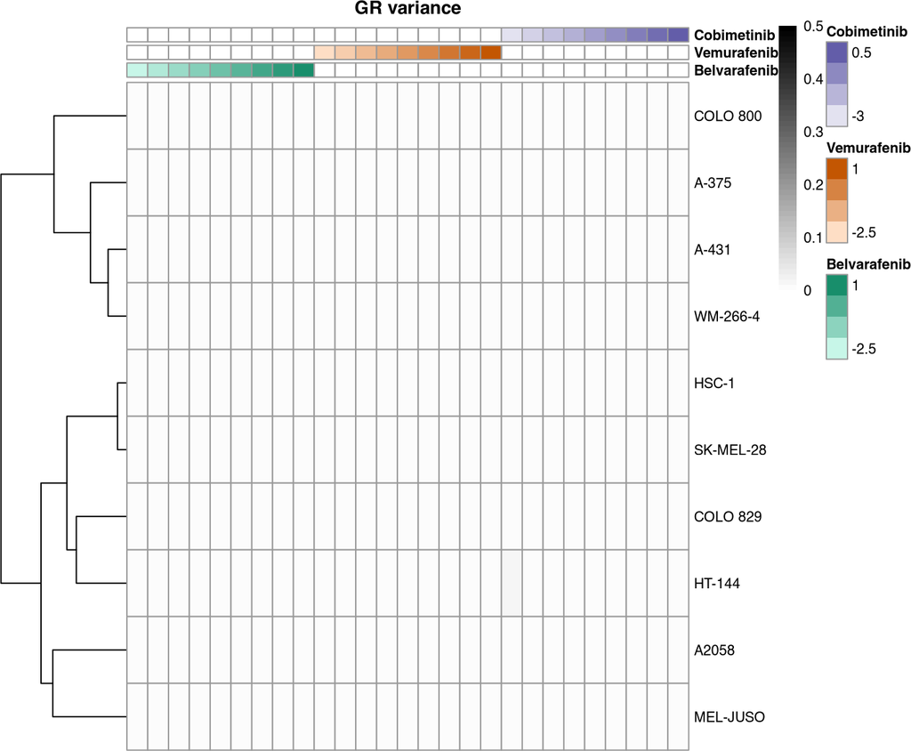

## 6.2 Quality Control: Averaged Data - Combination Data

```r
response_data_combo <- convert_se_assay_to_dt(se = se_combo,
                                              assay_name = "Averaged",
                                              unify_metadata = TRUE,
                                              merge_additional_variables = TRUE)

metrics$hm_title <- paste("RV", c("value", "variance"))
ls_plt_RV <- pmap(metrics,
                  pheatmap_qc,
                  dt_average = response_data_combo,
                  normalization_type = "RV",
                  lbl_by_CellLineName = TRUE, lbl_by_DrugName = TRUE)
names(ls_plt_RV) <- metrics$hm_title
```

```r
metrics$hm_title <- paste("GR", c("value", "variance"))
ls_plt_GR <- pmap(metrics,
                  pheatmap_qc,
                  dt_average = response_data_combo,
                  normalization_type = "GR",
                  lbl_by_CellLineName = TRUE, lbl_by_DrugName = TRUE)
names(ls_plt_GR) <- metrics$hm_title
```

### 6.2.1 Relative Viability

#### 6.2.1.1 RV value

🔍 Zoom In for Details

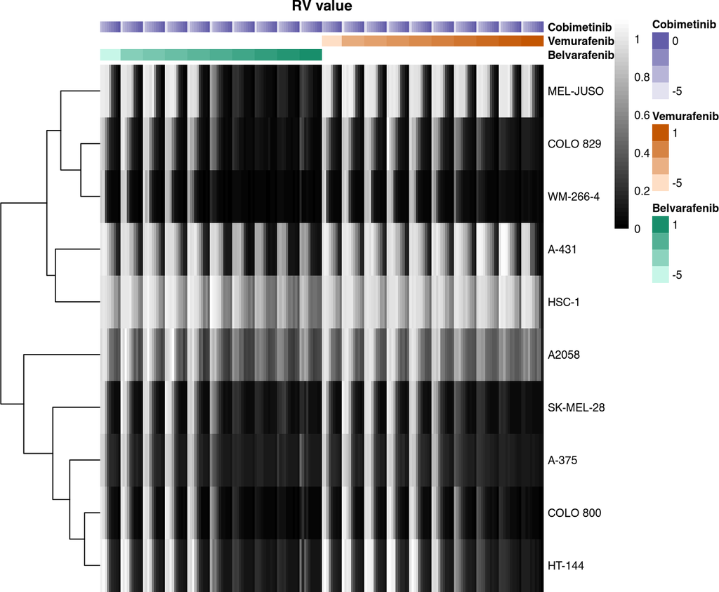

#### 6.2.1.2 RV variance

🔍 Zoom In for Details

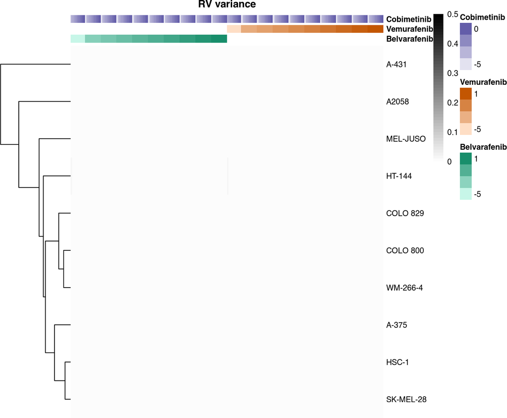

### 6.2.2 GR Value

#### 6.2.2.1 GR value

🔍 Zoom In for Details

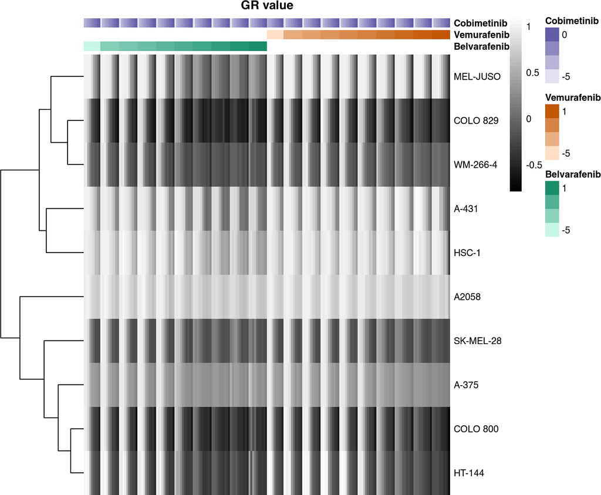

#### 6.2.2.2 GR variance

🔍 Zoom In for Details

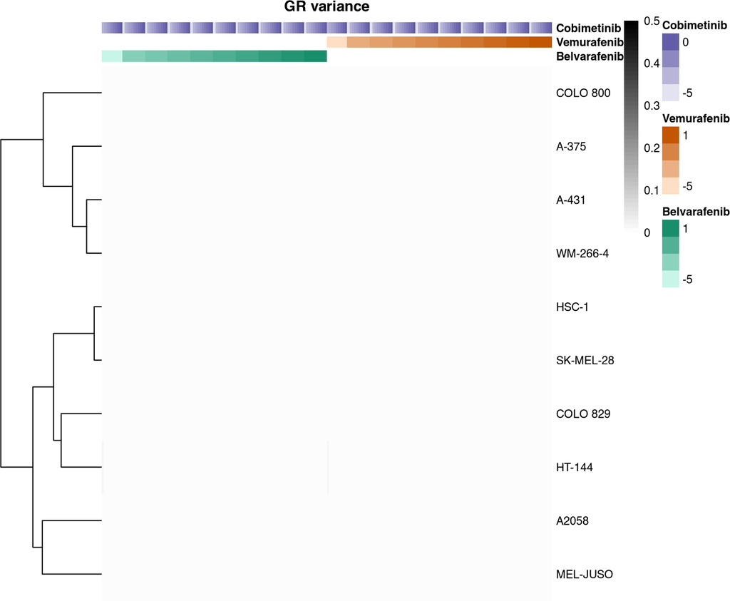

# 7 Fit Dose-Response Models

A sigmoidal dose-response model is fitted to the averaged data for each drug and cell line. From these fits, key sensitivity metrics are calculated and stored in several new assays:

- For **single-agent data**, this creates the `Metrics` assay, which contains values like IC50, GR50, Emax, and goodness-of-fit statistics.
- For **combination data**, this step generates a richer set of assays. In addition to the `Metrics` assay for each drug, it creates assays to describe synergy, such as `excess` (for Bliss/HSA excess calculations), `isobolograms`, and the final synergy `score`.

```r
se_sa <- fit_SE(se_sa, data_type = sa_name)
```

```r
se_combo <- fit_SE.combinations(se_combo, data_type = combo_name)
```

## 7.1 Quality Control - Accuracy of Fitting Dose-response Curves - Single-Agent Data

This is a **visual, qualitative check of individual curve shapes.** It shows the fitted dose-response curves overlaid on the averaged data points to assess how well the model fits the experimental data.

```r
response_metrics_sa <- convert_se_assay_to_dt(se = se_sa,
                                              assay_name = "Metrics",
                                              unify_metadata = TRUE,
                                              merge_additional_variables = TRUE)
cellline_vec <- sort(unique(response_metrics_sa[["CellLineName"]]))
cellline_vec_names <- vapply(cellline_vec, function(i) escape_special_characters(i),
                      FUN.VALUE = character(1))

ls_panel_RV <- pmap(list(cl_name = cellline_vec),
                    plot_dose_response_sa_qc_panel,
                    dt_metrics = response_metrics_sa,
                    dt_average = response_data_sa,
                    normalization_type = "RV")
names(ls_panel_RV) <- cellline_vec_names
```

```r
ls_panel_GR <- pmap(list(cl_name = cellline_vec),
                    plot_dose_response_sa_qc_panel,
                    dt_metrics = response_metrics_sa,
                    dt_average = response_data_sa,
                    normalization_type = "GR")
names(ls_panel_GR) <- cellline_vec_names
```

### 7.1.1 Relative Viability

#### 7.1.1.1 A-375

🔍 Zoom In for Details

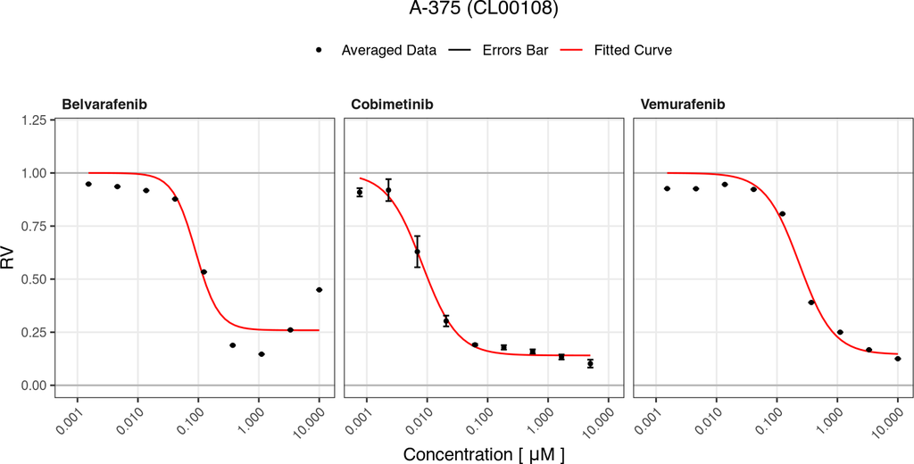

#### 7.1.1.2 A-431

🔍 Zoom In for Details

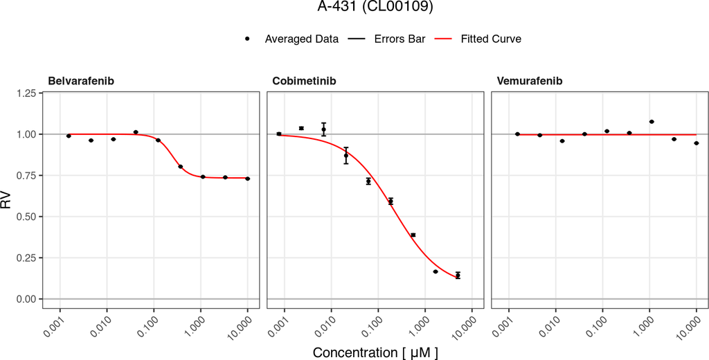

#### 7.1.1.3 A2058

🔍 Zoom In for Details

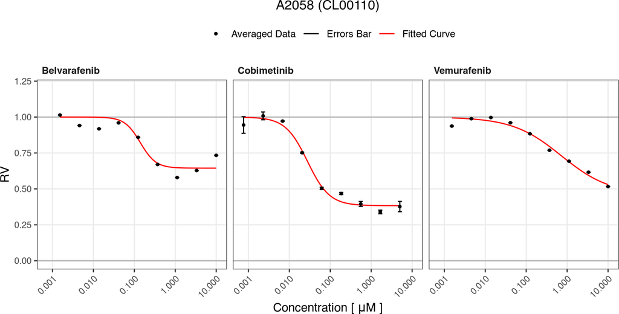

#### 7.1.1.4 COLO 800

🔍 Zoom In for Details

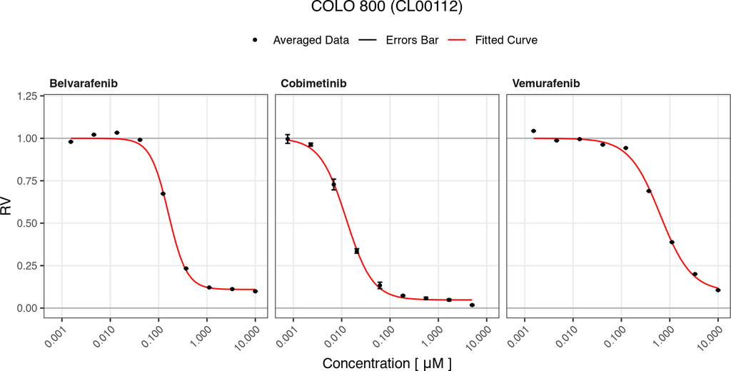

#### 7.1.1.5 COLO 829

🔍 Zoom In for Details

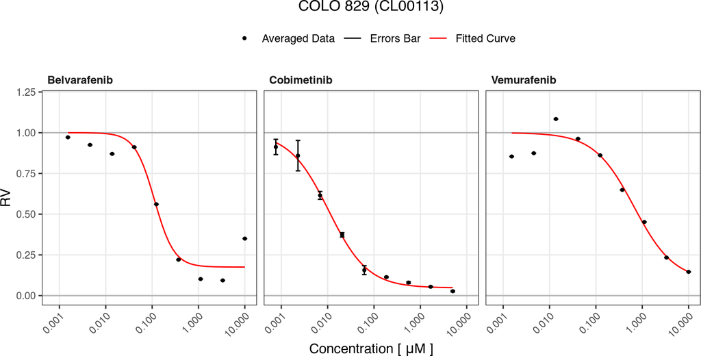

#### 7.1.1.6 HSC-1

🔍 Zoom In for Details

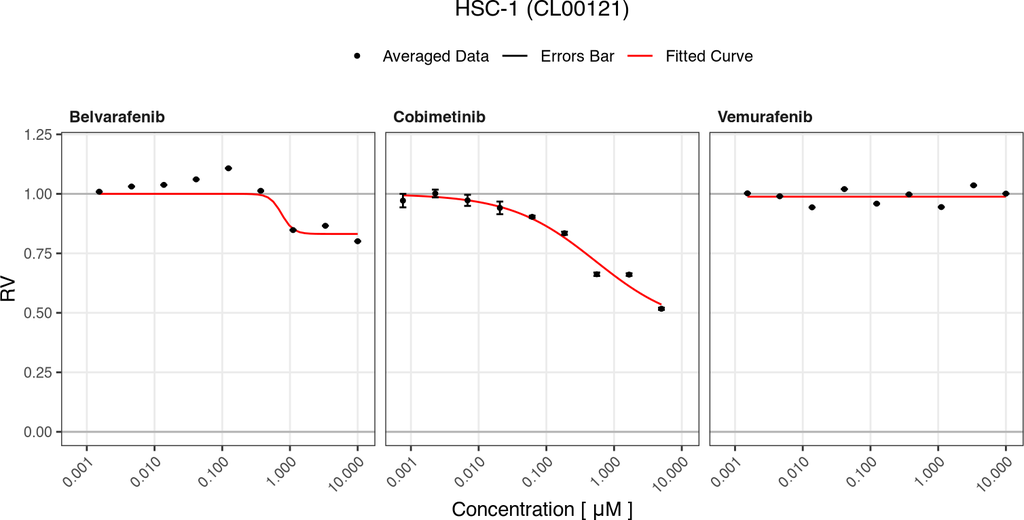

#### 7.1.1.7 HT-144

🔍 Zoom In for Details

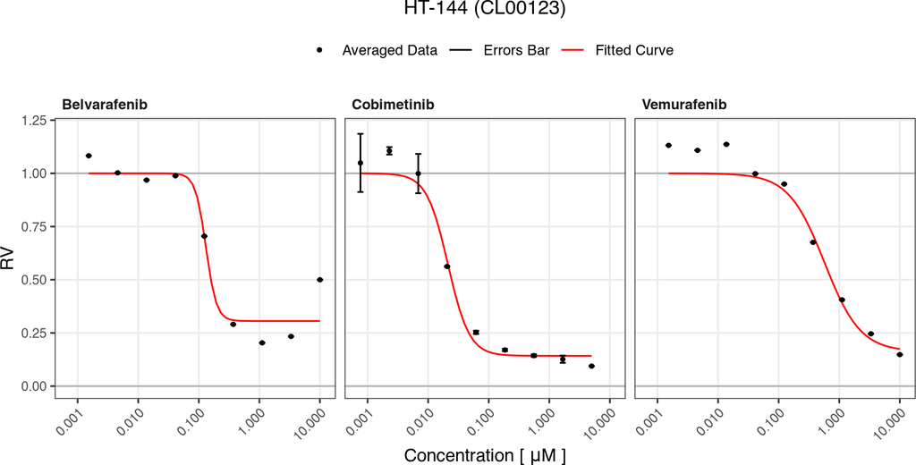

#### 7.1.1.8 MEL-JUSO

🔍 Zoom In for Details

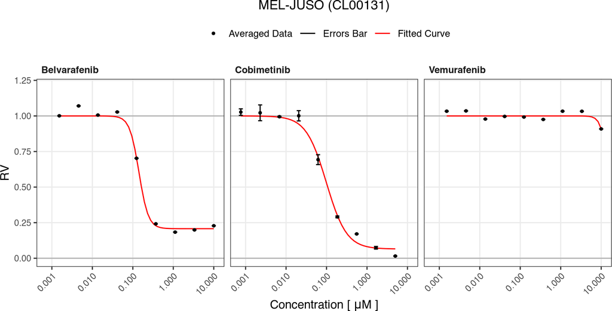

#### 7.1.1.9 SK-MEL-28

🔍 Zoom In for Details

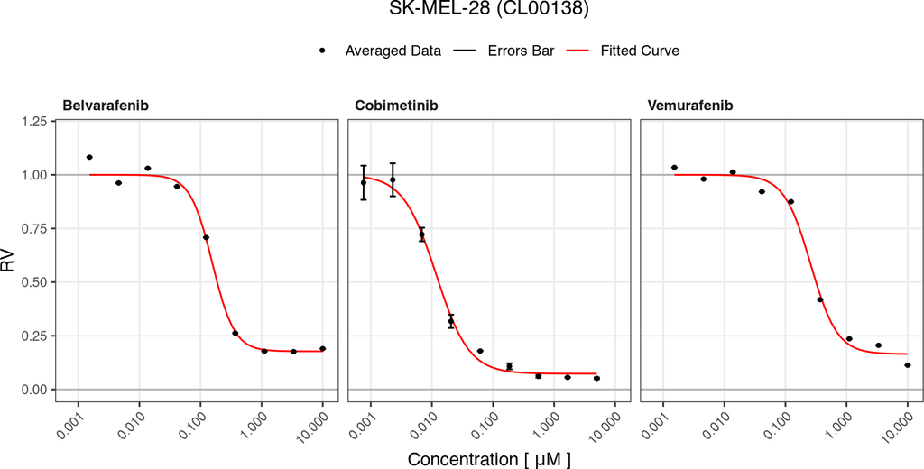

#### 7.1.1.10 WM-266-4

🔍 Zoom In for Details

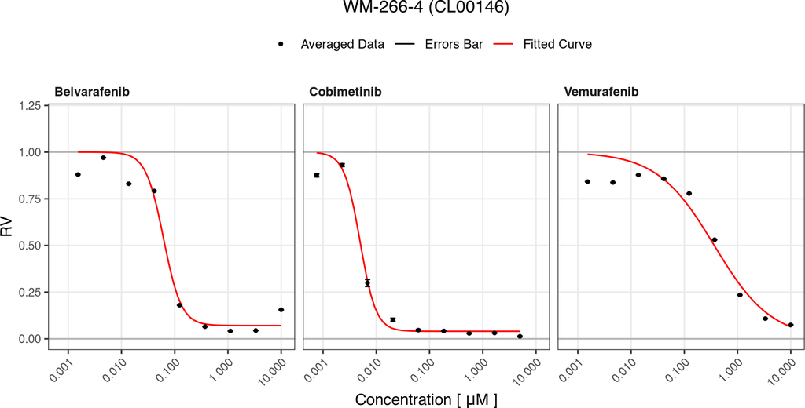

### 7.1.2 GR Value

#### 7.1.2.1 A-375

🔍 Zoom In for Details

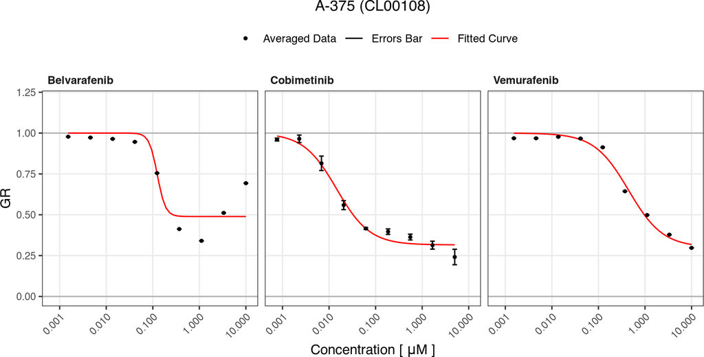

#### 7.1.2.2 A-431

🔍 Zoom In for Details

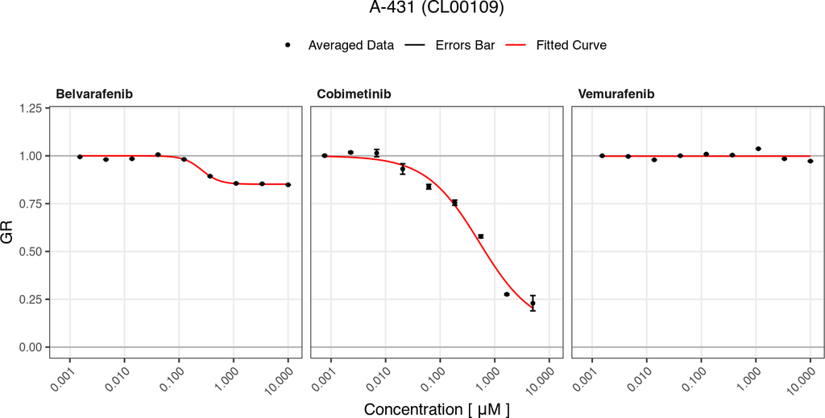

#### 7.1.2.3 A2058

🔍 Zoom In for Details

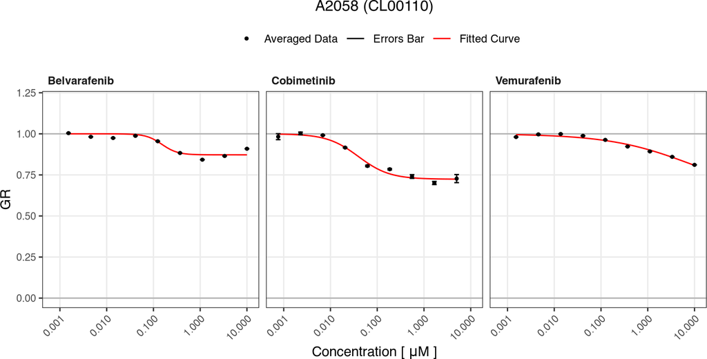

#### 7.1.2.4 COLO 800

🔍 Zoom In for Details

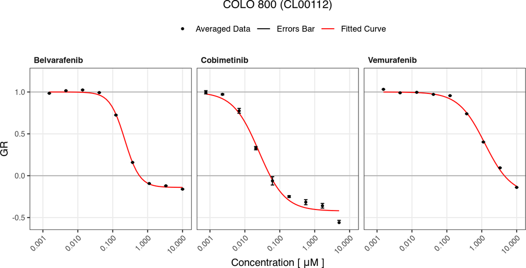

#### 7.1.2.5 COLO 829

🔍 Zoom In for Details

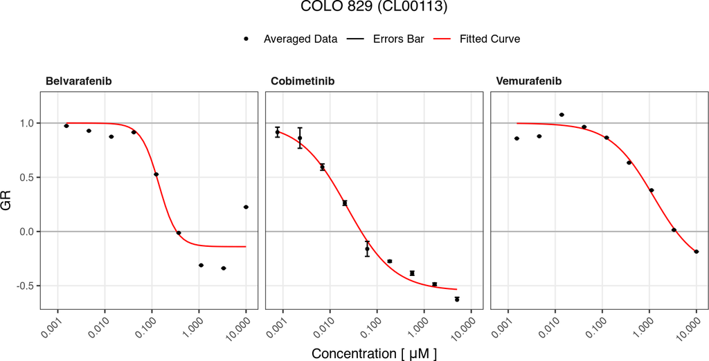

#### 7.1.2.6 HSC-1

🔍 Zoom In for Details

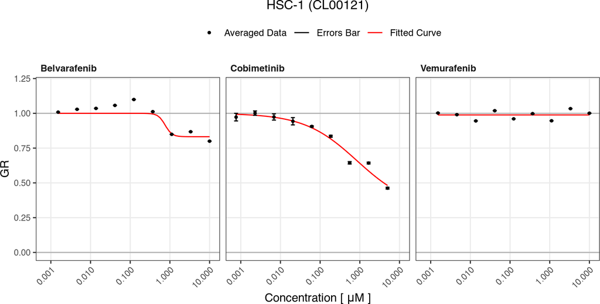

#### 7.1.2.7 HT-144

🔍 Zoom In for Details

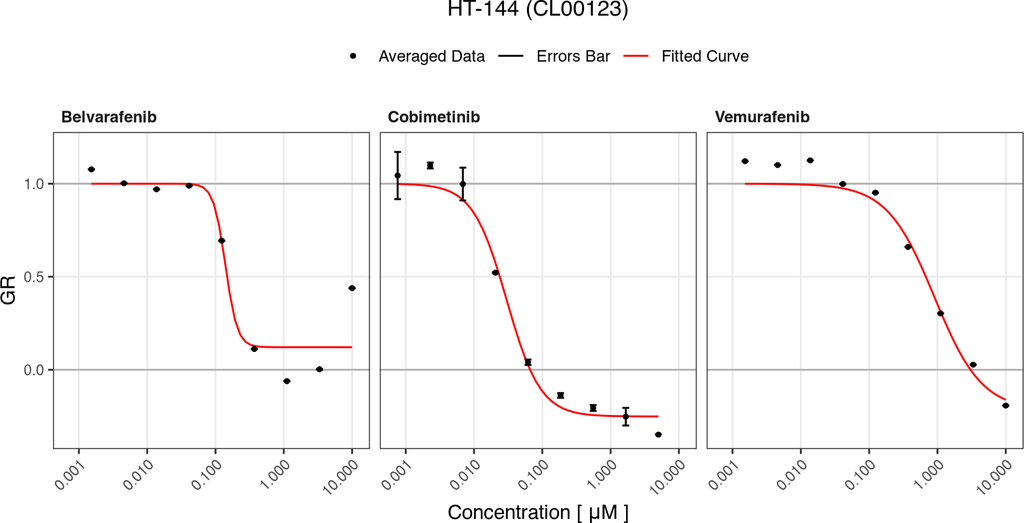

#### 7.1.2.8 MEL-JUSO

🔍 Zoom In for Details

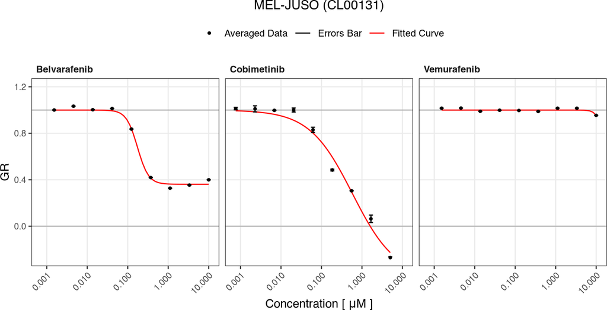

#### 7.1.2.9 SK-MEL-28

🔍 Zoom In for Details

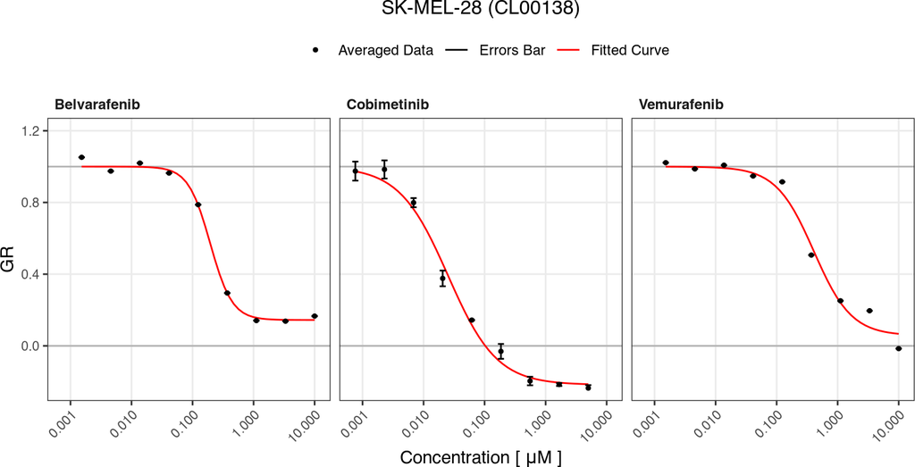

#### 7.1.2.10 WM-266-4

🔍 Zoom In for Details

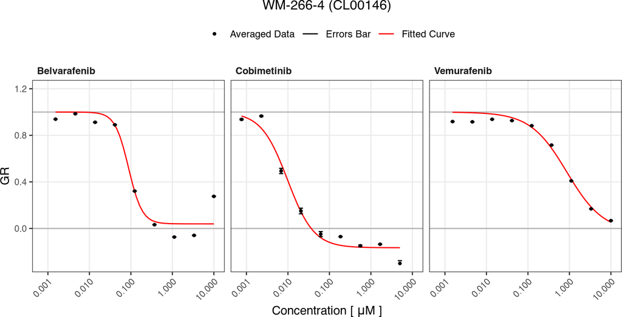

## 7.2 Quality Control - Fitting Precision - Single-Agent Data

This section provides a **quantitative summary of the model’s fitting quality** using two key statistical metrics: R-squared (R²) and Residual Sum of Squares (RSS). The metrics for each drug-cell line combination are displayed as a lollipop plot, which allows for easy comparison across different conditions.

**What to look for:** The lollipop plots allow for a quick comparison of fitting quality.

- **R-squared (R²):** This value represents the “goodness-of-fit.” **A value closer to 1 indicates a better fit**, meaning the model explains a high proportion of the variance in the data. Look for lollipops at the high end of the scale.
- **Residual Sum of Squares (RSS):** This value represents the overall error of the fit. **A lower RSS value indicates a better fit**, with less error between the model and the data. Look for lollipops at the low end of the scale.

```r
cellline_vec <- sort(unique(response_metrics_sa[["CellLineName"]]))
cellline_vec_names <- vapply(cellline_vec, function(i) escape_special_characters(i),
                      FUN.VALUE = character(1))

ls_plt_RV <- pmap(list(cl_name = cellline_vec),
                  plot_fitting_acc,
                  dt_assay = response_metrics_sa,
                  normalization_type = "RV")
names(ls_plt_RV) <- cellline_vec_names
```

```r
ls_plt_GR <- pmap(list(cl_name = cellline_vec),
                  plot_fitting_acc,
                  dt_assay = response_metrics_sa,
                  normalization_type = "GR")
names(ls_plt_GR) <- cellline_vec_names
```

### 7.2.1 Relative Viability

#### 7.2.1.1 A-375

🔍 Zoom In for Details

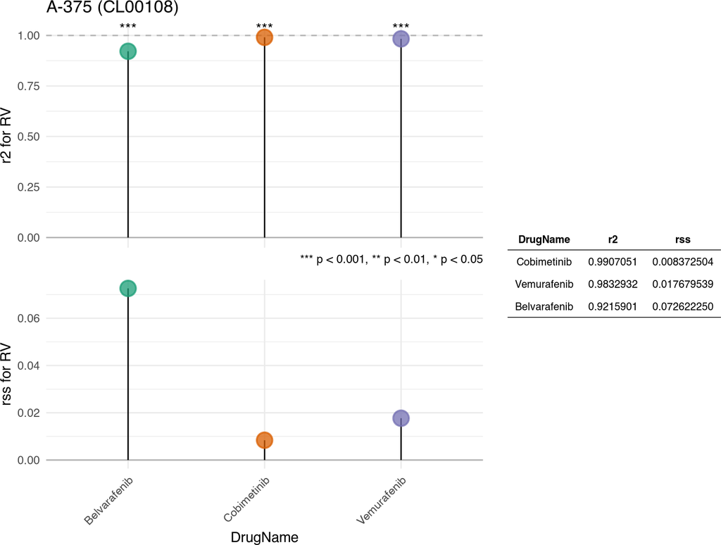

#### 7.2.1.2 A-431

🔍 Zoom In for Details

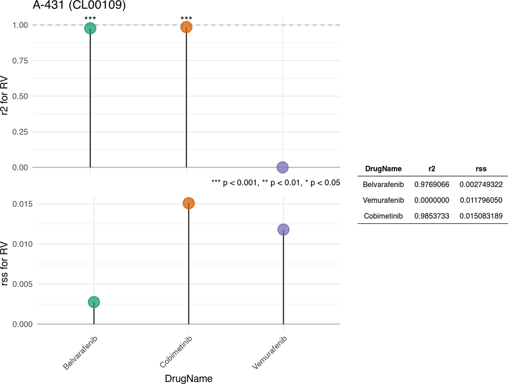

#### 7.2.1.3 A2058

🔍 Zoom In for Details

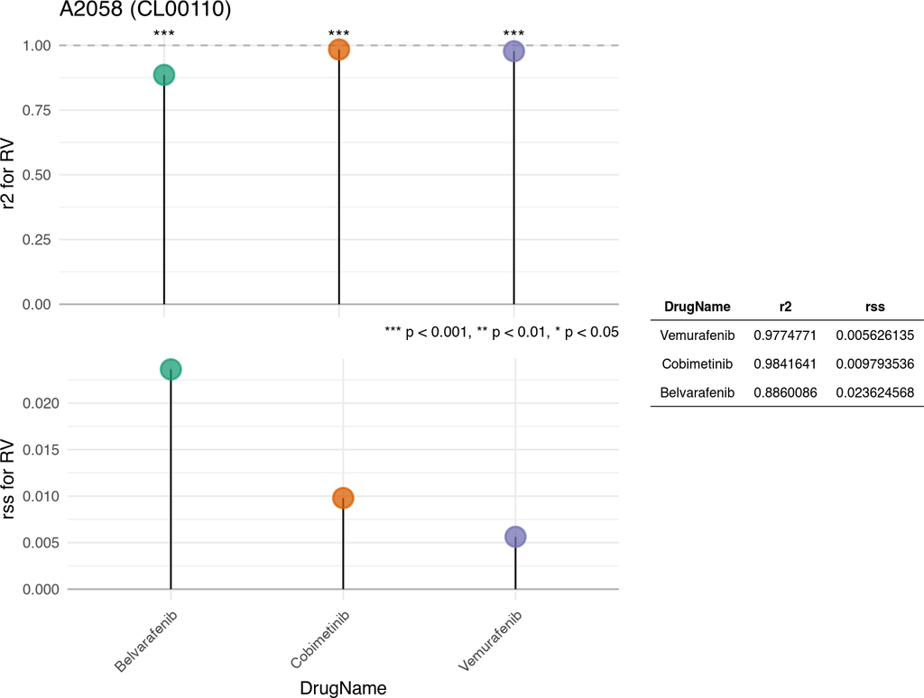

#### 7.2.1.4 COLO 800

🔍 Zoom In for Details

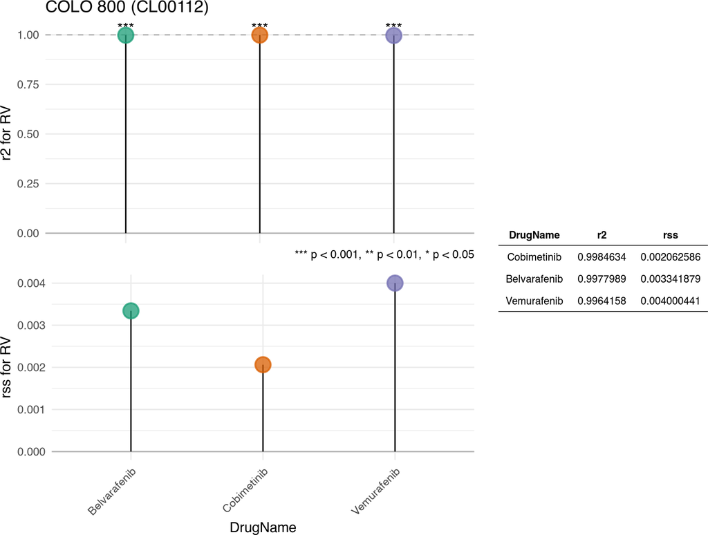

#### 7.2.1.5 COLO 829

🔍 Zoom In for Details

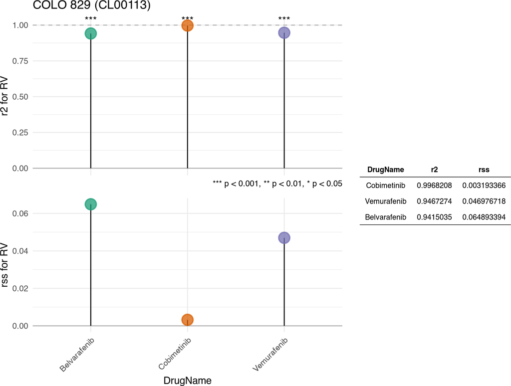

#### 7.2.1.6 HSC-1

🔍 Zoom In for Details

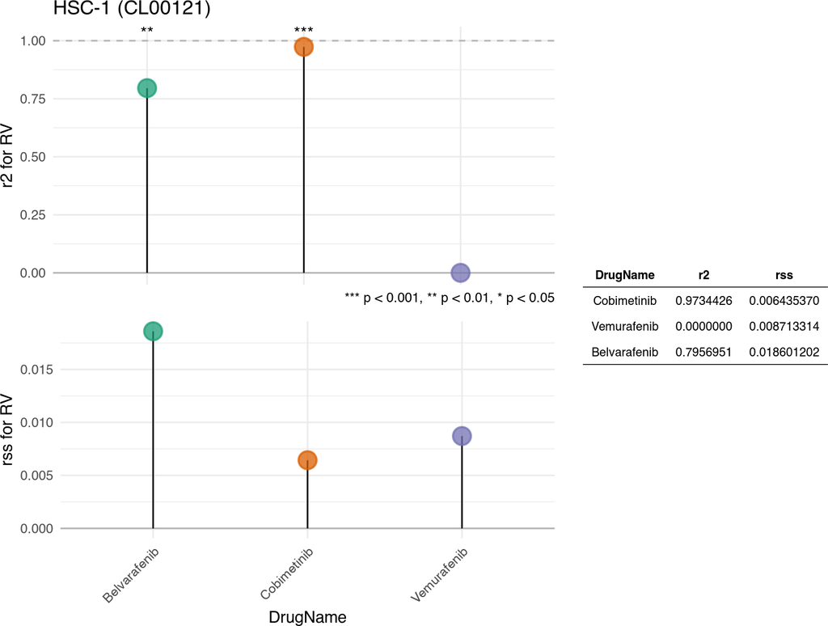

#### 7.2.1.7 HT-144

🔍 Zoom In for Details

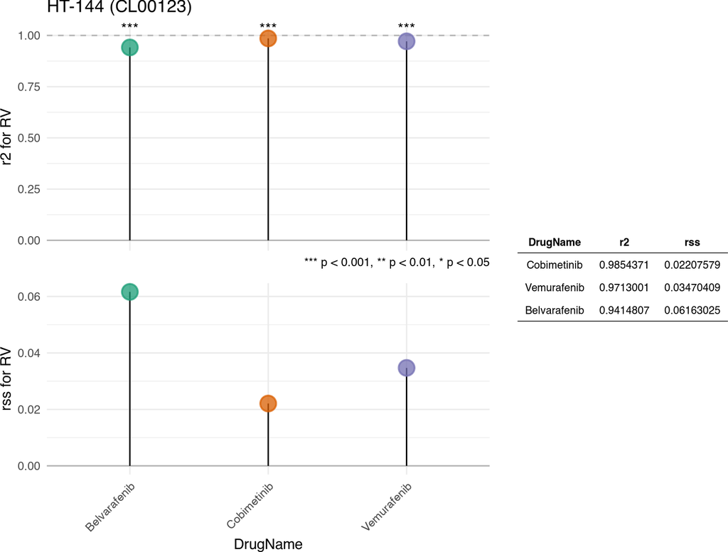

#### 7.2.1.8 MEL-JUSO

🔍 Zoom In for Details

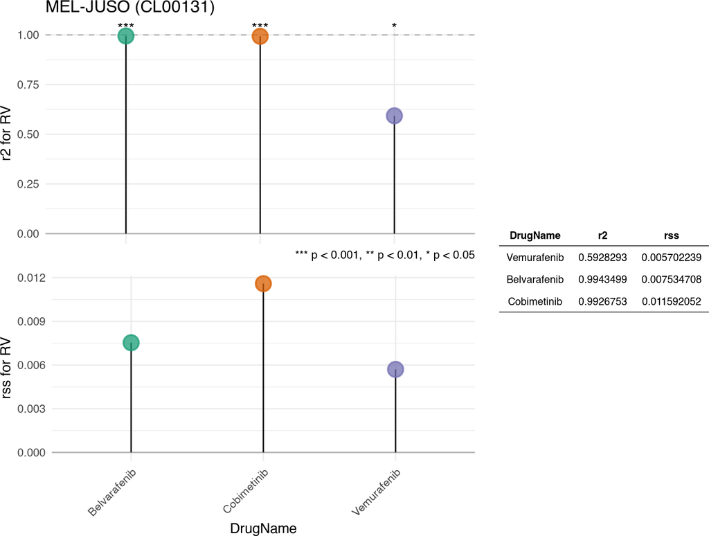

#### 7.2.1.9 SK-MEL-28

🔍 Zoom In for Details

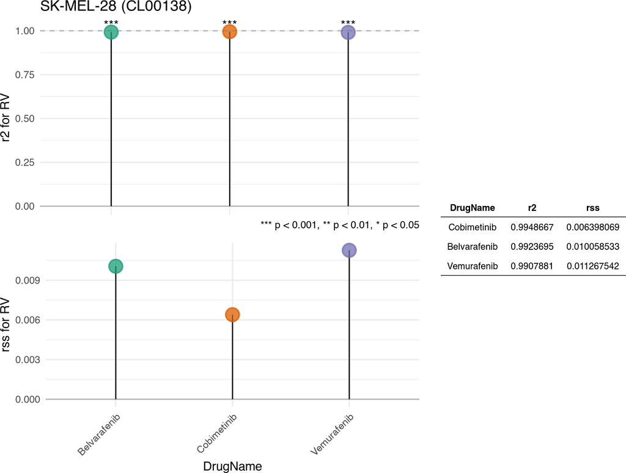

#### 7.2.1.10 WM-266-4

🔍 Zoom In for Details

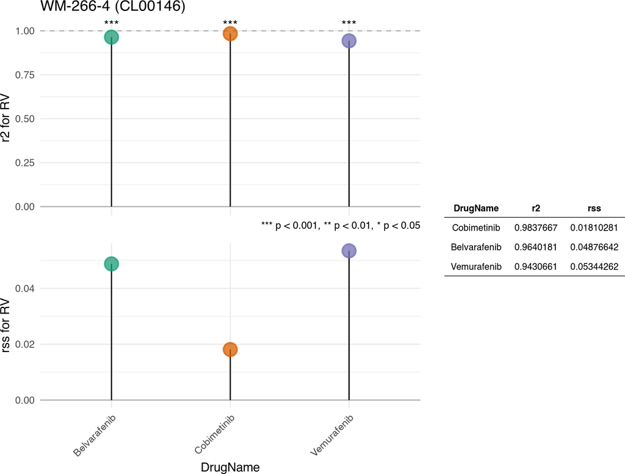

### 7.2.2 GR Value

#### 7.2.2.1 A-375

🔍 Zoom In for Details

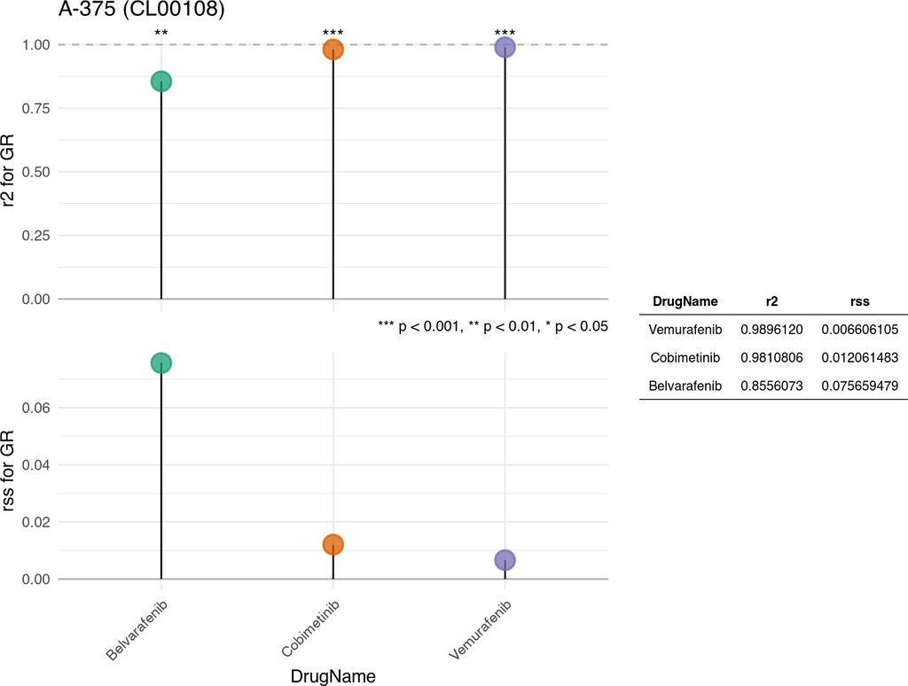

#### 7.2.2.2 A-431

🔍 Zoom In for Details

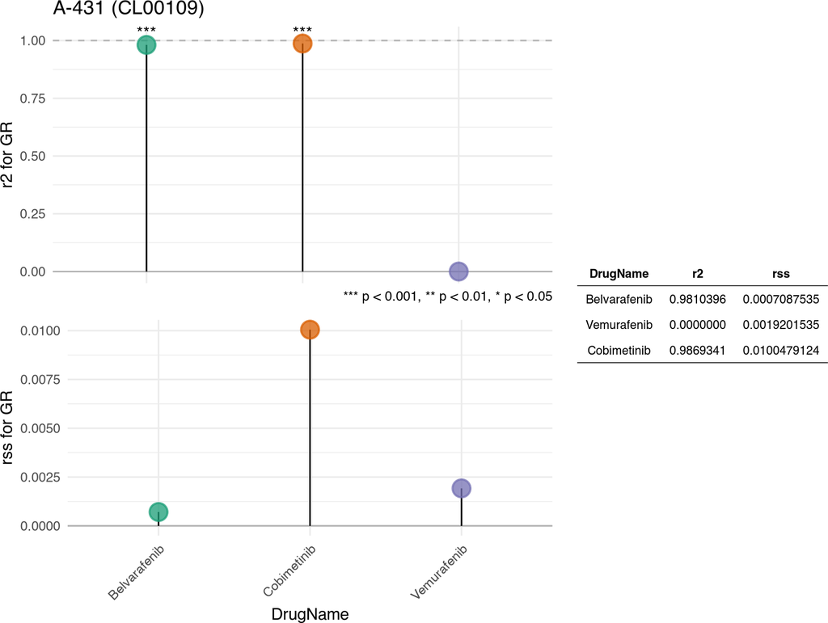

#### 7.2.2.3 A2058

🔍 Zoom In for Details

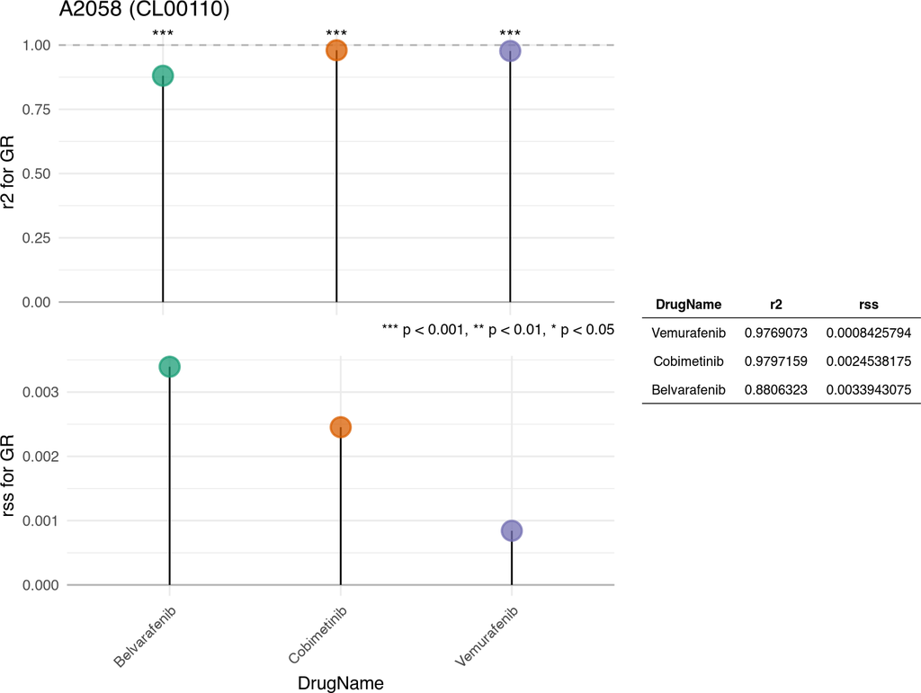

#### 7.2.2.4 COLO 800

🔍 Zoom In for Details

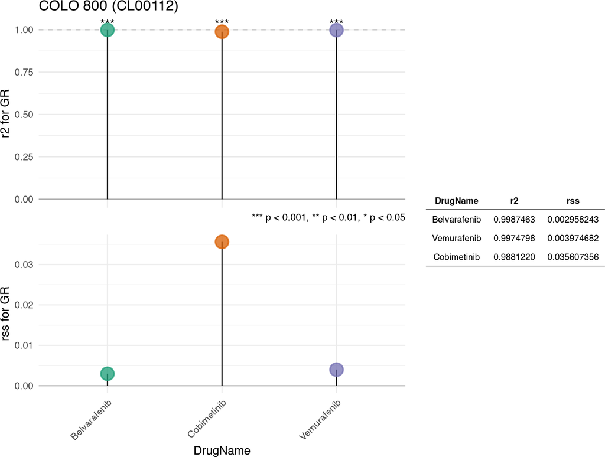

#### 7.2.2.5 COLO 829

🔍 Zoom In for Details

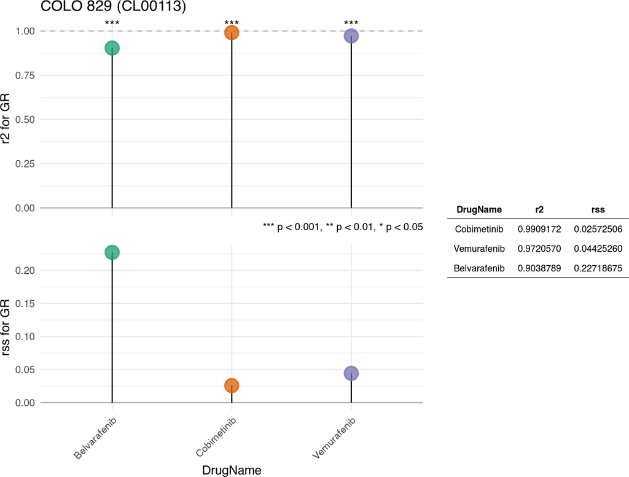

#### 7.2.2.6 HSC-1

🔍 Zoom In for Details

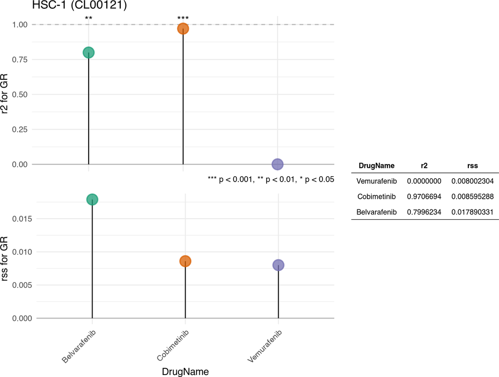

#### 7.2.2.7 HT-144

🔍 Zoom In for Details

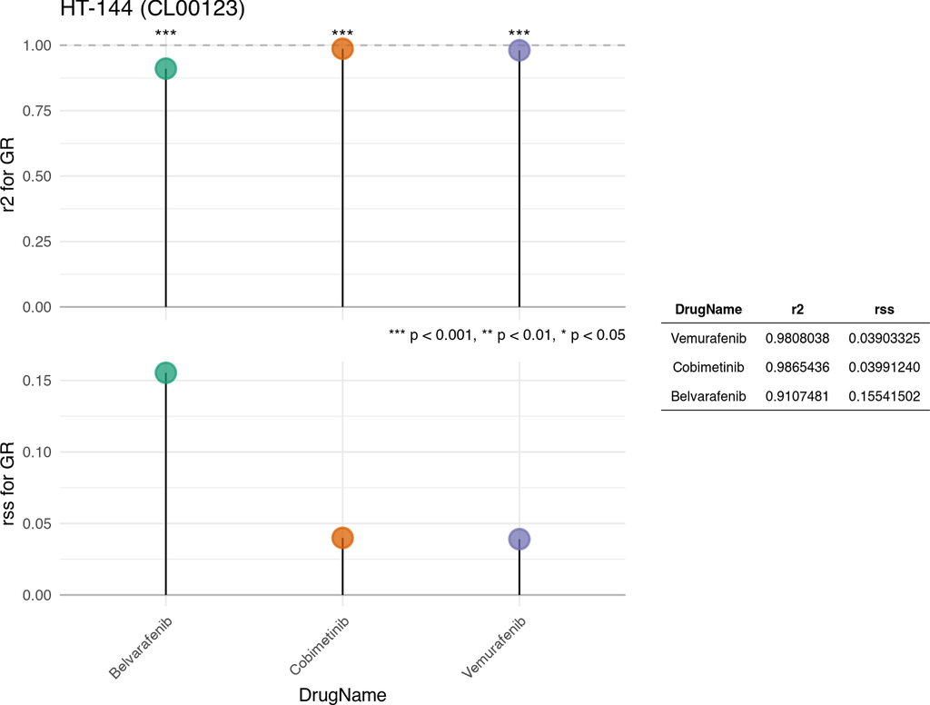

#### 7.2.2.8 MEL-JUSO

🔍 Zoom In for Details

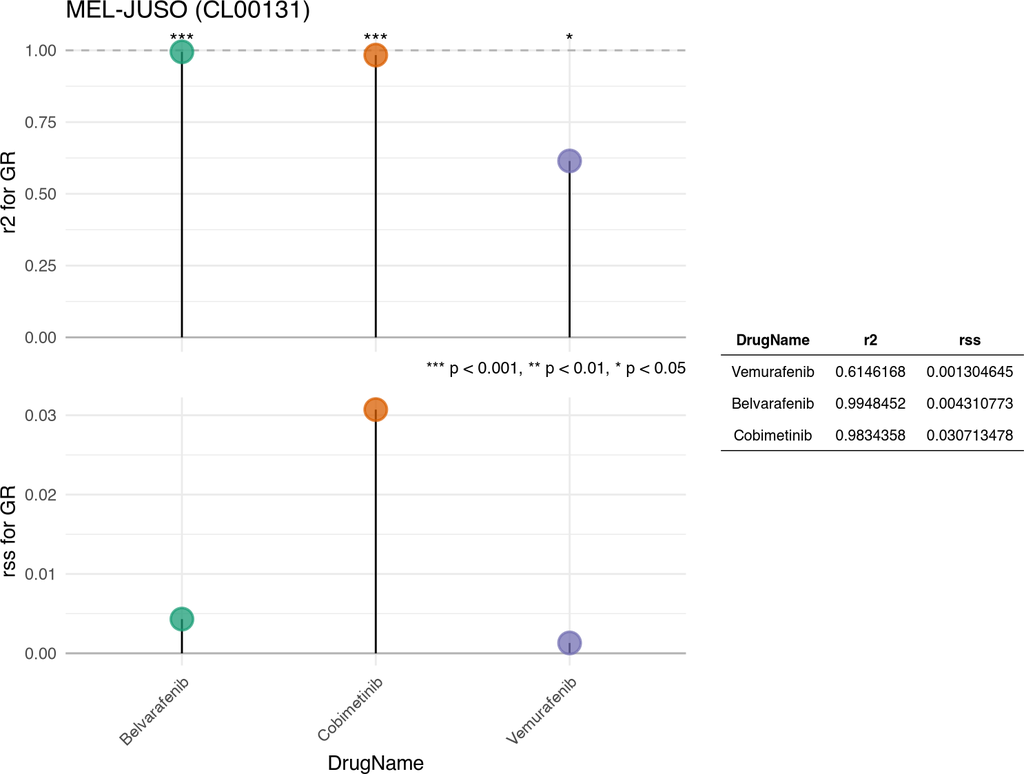

#### 7.2.2.9 SK-MEL-28

🔍 Zoom In for Details

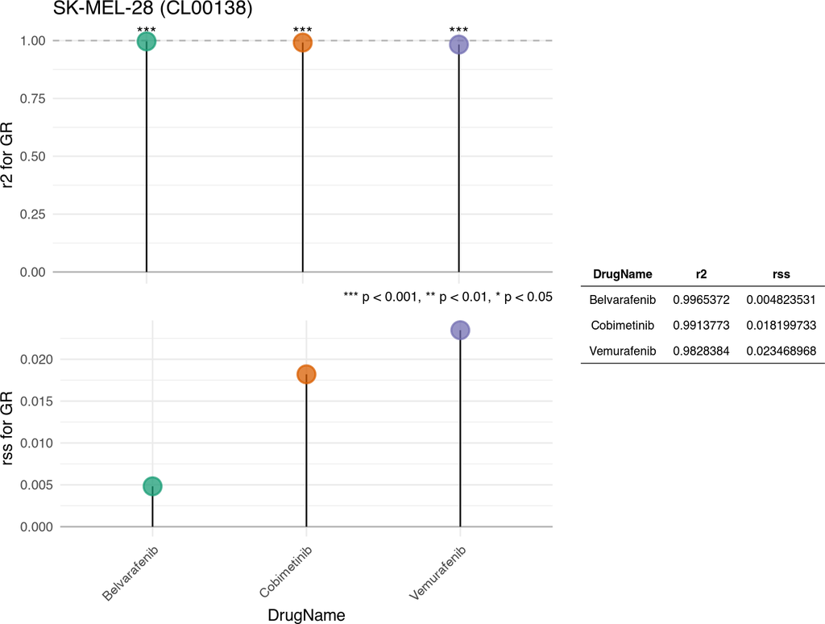

#### 7.2.2.10 WM-266-4

🔍 Zoom In for Details

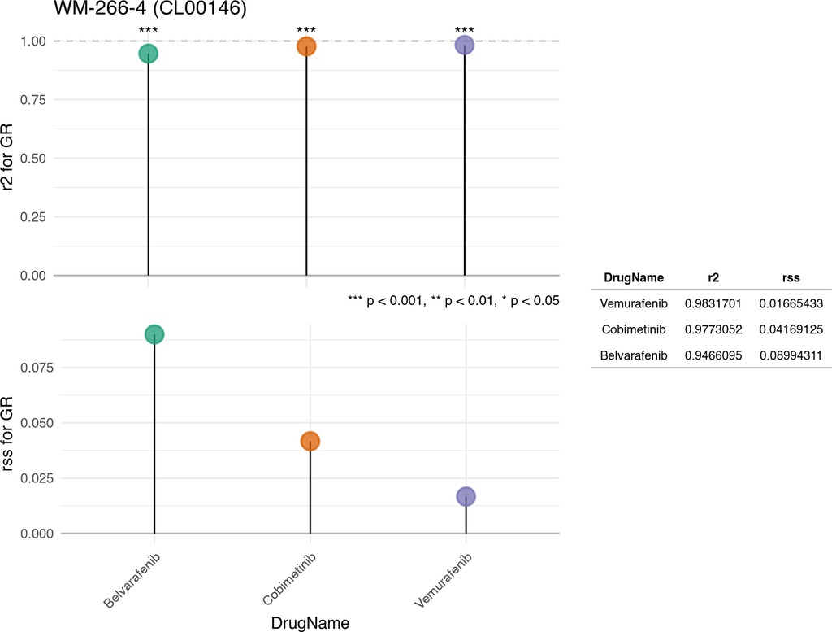

# 8 Assemble and Save Final Results

Finally, all processed data and results are combined into a single `MultiAssayExperiment` (MAE) object. The MAE is a flexible container that holds all `SummarizedExperiment` objects, ensuring all data and metadata are stored together in an organized and accessible format.

```r
mae <- if (exists("se_combo") && !is.null(se_combo)) {
  MultiAssayExperiment(experiments = setNames(list(se_sa, se_combo), c(sa_name, combo_name)))
} else {
  MultiAssayExperiment(experiments = setNames(list(se_sa), c(sa_name)))
}
mae <- standardize_mae(mae)
qs_save(mae, file.path(wd, "gDR_data", "gDR_mae.qs2"))
```

Please note: Steps 5 through 9 can be automatically executed using the runDrugResponseProcessingPipeline function, which handles all stages of the pipeline for all identified data types.”

# 9 Conclusion

The data processing and dose-response fitting are complete. The final, comprehensive results are stored in the `MultiAssayExperiment` object located at `gDR_data/gDR_mae.qs2`. This object contains all data layers (raw, normalized, averaged, and metrics) and is ready for downstream biological interpretation and visualization.

### We Value Your Feedback!

Thank you for using gDR! We are always looking to improve, and your feedback is incredibly valuable to us.

[Share feedback or request features on GitHub](https://github.com/gdrplatform/gDRworkshops/issues)

# 10 gDR session info

```r
gdr_elapsed <- (proc.time() - gdr_start_time)[["elapsed"]]
message(sprintf("Report generated in %.1f seconds", gdr_elapsed))
gdr_sdt <- get_gDR_session_info()
generate_datatable(gdr_sdt)
```

|  | Package | Version |
| --- | --- | --- |
| 1 | gDR | 1.11.2 |
| 2 | gDRcomponents | 1.4.126 |
| 3 | gDRcore | 1.11.5 |
| 4 | gDRimport | 1.11.3 |
| 5 | gDRin | 0.2.96 |
| 6 | gDRiPlots | 0.0.24 |
| 7 | gDRplots | 0.0.111 |
| 8 | gDRsearch | 1.3.40 |
| 9 | gDRsearch2 | 0.1.100 |
| 10 | gDRtestData | 1.6.0 |

[output cut: 2 more lines]

```r
cat(sprintf("**Report generation time: %.1f seconds**", gdr_elapsed))
```

```
## **Report generation time: 58.6 seconds**
```